# Diabetes Melitus Tipo II

Sebastian Morales Peralta 000124317

27 de marzo de 2015

### REPORTE TECNICO

#### I. Introduccion

Este reporte busca presentar, de forma general, el fenomoeno de la Diabetes melitus tipo II (no insulinodependiente) en Mexico. Los datos contenidos abarcan el periodo 2003 a 2013 y son publicados por la Secretaria de Salud en la pagina:  
http://www.epidemiologia.salud.gob.mx/anuario/html/anuarios.html

En esta seccion se encuentra una breve descripcion de los datos para pasar, mas adelate, a la definicion del problema.

La base de datos esta compuesta por 3 tablas principales, presentadas a continuacion, describen los casos de diabetes reportados de 2003 a 2013. La informacion esta distribuida en dos generos sexuales (masculino y femenino) en las 32 entidades del pais.

FUENTE.  
Informacion dividida por las distintas instituciones que reportaron los casos de diabetes.

```
##                estado  genero fecha fuente casos
## 1       Aguscalientes General  2003  salud  1859
## 2     Baja California General  2003  salud  2443
## 3 Baja California Sur General  2003  salud   646
## 4            Campeche General  2003  salud  1188
## 5            Coahuila General  2003  salud  1346
## 6              Colima General  2003  salud   802
```

```
## [1] "salud"    "imss.ord" "issste"   "imss.op"  "dif"      "pemex"
## [7] "sedena"   "semar"    "otras"
```

MES.  
La informacion se encuantra dividida por cada mes del anio.

```
##                estado  genero fecha mes casos
## 1       Aguscalientes General  2003 ene   268
## 2     Baja California General  2003 ene  1049
## 3 Baja California Sur General  2003 ene   171
## 4            Campeche General  2003 ene   206
## 5            Coahuila General  2003 ene  1299
## 6              Colima General  2003 ene   174
```

EDAD.  
Presenta los casos de diabetes reportados en los distintos grupos de edad, donde ign se refiere a aquellos individuos que no fueron clasifiados en un grupo de edad.

```
##                estado  genero fecha edad casos
## 1       Aguscalientes General  2003   <1     0
## 2     Baja California General  2003   <1     0
## 3 Baja California Sur General  2003   <1     0
## 4            Campeche General  2003   <1     0
## 5            Coahuila General  2003   <1     2
## 6              Colima General  2003   <1     0
```

```
##  [1] "<1"    "1a4"   "5a9"   "10a14" "15a19" "20a24" "25a44" "45a49"
##  [9] "50a59" "60a64" "65+"   "ign"
```

Nota: se omitieron la mayoria de los acentos en el presente reporte, debido a que eran cambiados por “??” automaticamente por el sistema.

#### II. Definicion del Problema.

El principal objetivo de este reporte es presentar el fenomeno de la diabetes melitus tipo II en Mexico, por lo cual iniciaremos haciendo las preguntas mas generales, hasta llegar a responder las preguntas mas especificas que nuestros datos nos permitan.

1. Es importante conocer como se distribuyen todos nuestros casos reportados de diabetes entre hombres y mujeres de la poblacion.
2. Cual es el estado de la republica que presenta mayores casos de diabetes en Mexico; asi como aquel estado que presenta los menores casos.
3. Presentar la tendencia, a lo largo del tiempo, de los casos reportados en el periodo 2003 - 2013, ??es creciente o decreciente?
4. ??En que anio se reporto el mayor y menor numero de casos de diabetes en Mexico?
5. ??Cual es el comportamiento, de los casos reportados, en las distintas edades de la poblacion? ??En que grupo de edad se encuentra el mayor numero de casos de diabetes?  
   6.??Cuales son las instituciones en la republica donde se han reportado el mayor y menor numero de casos?
6. ??Como es el comportamiento mensual de los casos reportados? ??Existe algun tipo de estacionalidad?
7. Cual es el comportamiento de los casos en hombre y mujeres a lo largo del tiempo y en cada uno de los estados de la republica?
8. Cual es el comportamiento de los distintos grupos de edad a lo largo del tiempo y en cada una de las entidades del pais?

Cada una de estas preguntas ser respondida mediante un analisis exploratorio, el cual nos permita entender el comportamiento de los casos de diabetes en la poblacion mexicana a lo largo del tiempo, por lo que se incluiran datos de promedios y varianzas para comenzar a “visualizar” que tan solido sera el analisis en la etapa inferencial (no presentada en el actual reporte).

#### III. Obtencion y Descripcion de los Datos.

Una base de datos “ideal” que podria responder todas las preguntas de manera puntual seria aquella que contuviera los siguientes campos o variables:

```
## [1] "estado" "genero" "fecha"  "mes"    "fuente" "edad"   "casos"
```

En la cual, las variables serian de los siguientes tipos y escalas:  
ESTADO.  
Esta variable es de tipo categorica y da cuenta de cada uno de los estados de la republica mexicana.

```
##  [1] "Aguscalientes"       "Baja California"     "Baja California Sur"
##  [4] "Campeche"            "Coahuila"            "Colima"
##  [7] "Chiapas"             "Chihuahua"           "Distrito Federal"
## [10] "Durango"             "Guanajuato"          "Guerrero"
## [13] "Hidalgo"             "Jalisco"             "Mexico"
## [16] "Michoacan"           "Morelos"             "Nayarit"
## [19] "Nuevo Leon"          "Oaxaca"              "Puebla"
## [22] "Queretaro"           "Quintana Roo"        "San Luis Potosi"
## [25] "Sinaloa"             "Sonora"              "Tabasco"
## [28] "Tamaulipas"          "Tlaxcala"            "Veracruz"
## [31] "Yucatan"             "Zacatecas"
```

GENERO.  
El sexo de de los individuos reportados con diabetes melitus tipo II. Es una variable categorica.

```
## [1] "General" "Mujeres" "Hombres"
```

FECHA.  
Se refiere al anio en el que se presentaron los casos de diabetes, es una variable numerica, de tipo entero, que se encuantra entre los rangos 2003 y 2013.

```
##  [1] 2003 2004 2005 2006 2007 2008 2009 2010 2011 2012 2013
```

MES.  
El mes del anio en el que se reportaron los casos, es una variable de tipo caracter que contiene cada uno de los meses del anio.

```
##  [1] "ene" "feb" "mar" "abr" "may" "jun" "jul" "ago" "sep" "oct" "nov"
## [12] "dic"
```

FUENTE.  
Es una variable categorica que permite saber el numero de casos reportados por algunas instituciones del pais.

```
## [1] "salud"    "imss.ord" "issste"   "imss.op"  "dif"      "pemex"
## [7] "sedena"   "semar"    "otras"
```

EDAD.  
Variable categorica que agrupa distintos rangos de edades que presentan casos de diabetes. En este caso, la categoria “ign” se refiere a todas aquellas personas que no fueron asignadas a algun grupo de edad.

```
##  [1] "<1"    "1a4"   "5a9"   "10a14" "15a19" "20a24" "25a44" "45a49"
##  [9] "50a59" "60a64" "65+"   "ign"
```

CASOS.  
Es la variable dependiente, es de tipo numerica y se refiere al numero de personas que reflejan un caso de diabetes melitus tipo II (no insulinodependiente). Para este reporte, la variable se encuentra en los siguentes rangos:

```
##       min   max
## casos   0 28024
```

Este reporte contiene todas estas variables, sin embargo, no se tienen integradas en una sola base de datos, por lo que no es posible dar respuestas tan especificas como por ejemplo:  
Cuantos casos de hombres con diabetes se reportaron en abril de 2008 en el issste en Durango?  
Ya que la informacion actual puede dar cuenta de los hombres reportados en abril de 2008 y los hombres reportados en el 2008 por parte del issste pero a lo largo de todo el anio.  
ej.

```
##       estado  genero fecha mes casos
## 3690 Durango Hombres  2008 abr   269
```

```
##       estado  genero fecha fuente casos
## 2986 Durango Hombres  2008 issste   566
```

Por lo tanto, utilizaremos las tres bases por separado (fuente, mes, edad) para responder de las preguntas mas generales hasta la mas particular que sea posible.

#### IV Calidad de los Datos.

En esta seccion se mostrara la calidad de los datos presentados, es decir, que los datos de cada una de nuestras tablas (fuente, mes, edad) sean los mismos para cada anio, genero, y estado. Esto con el fin de corrobrar que los datos que estamos utilizando coinciden, independientemente de la tabla que estemos utilizando, lo cual nos permite tener solidez en el analisis comparativo.

Primero mostraremos que, para cada tabla, los datos son los mismos para cada anio y cada genero.  
Por fuente.

```
##    Fecha General Hombres Mujeres  Total Diferencia
## 1   2003  380332  147171  233161 380332          0
## 2   2004  404562  156916  247646 404562          0
## 3   2005  397387  152621  244766 397387          0
## 4   2006  394360  152836  241524 394360          0
## 5   2007  404770  160068  244702 404770          0
## 6   2008  396374  158992  237382 396374          0
## 7   2009  426802  177825  248977 426802          0
## 8   2010  420032  173507  246525 420032          0
## 9   2011  427125  176891  250234 427125          0
## 10  2012  419493  173725  245768 419493          0
## 11  2013  397192  166220  230972 397192          0
```

Por mes.

```
##    Fecha General Hombres Mujeres  Total Diferencia
## 1   2003  380332  147171  233161 380332          0
## 2   2004  404562  156916  247646 404562          0
## 3   2005  397387  152621  244766 397387          0
## 4   2006  394360  152836  241524 394360          0
## 5   2007  404770  160068  244702 404770          0
## 6   2008  396374  158992  237382 396374          0
## 7   2009  426802  177825  248977 426802          0
## 8   2010  420032  173507  246525 420032          0
## 9   2011  427125  176891  250234 427125          0
## 10  2012  419493  173725  245768 419493          0
## 11  2013  397192  166220  230972 397192          0
```

Por edad.

```
##    Fecha General Hombres Mujeres  Total Diferencia
## 1   2003  380332  147171  233161 380332          0
## 2   2004  404562  156916  247646 404562          0
## 3   2005  397387  152621  244766 397387          0
## 4   2006  394360  152836  241524 394360          0
## 5   2007  404770  160068  244702 404770          0
## 6   2008  396374  158992  237382 396374          0
## 7   2009  426802  177825  248977 426802          0
## 8   2010  420032  173507  246525 420032          0
## 9   2011  427125  176891  250234 427125          0
## 10  2012  419493  173725  245768 419493          0
## 11  2013  397192  166220  230972 397192          0
```

Nota: Total = Hombres + Mujeres  
Nota: Diferencia = Total - General

En total, para cada genero y en cada anio, podemos observar que los datos son los mismos para cada una de las tablas (fuente, mes y edad). Y en un primer analisis nos estaria diciendo el total de hombres y mujeres reportados con un caso de diabetes melitus tipo II, asi como el total de personas reportadas en el periodo.

```
## Hombres Mujeres   Total
## 1796772 2671657 4468429
```

```
## Hombres Mujeres   Total
## 1796772 2671657 4468429
```

```
## Hombres Mujeres   Total
## 1796772 2671657 4468429
```

#### V. Transformacion de los Datos.

Los datos que tenemos estan listos para comenzar el analisis exploratorio, simplemente extraeremos las variables de lo general a lo particular, dependiendo de la o las preguntas que se deban contestar.  
ej. Casos de hombres reportados por el DIF.

```r
hombresDif <- subset(fuente, genero == "Hombres" & fuente == "dif")$casos
sum(hombresDif)
```

```
## [1] 27081
```

Sin embargo, en esta seccion se explica el proceso que se llevo a cabo para obtener los datos listos para utilizarse.

##### V.I. Extraccion de los Datos.

Primero, se llevo a cabo la extraccion de los datos desde la pagina de la Secretaria de Salud:  
http://www.epidemiologia.salud.gob.mx/anuario/html/anuarios.html  
Fueron descargados 99 archivos PDF que contienen la informacion de los casos de diabetes reportados para hombres, mujeres y a nivel general para los anios 2003 a 2013, dependiendo de la categoria seleccionada: Grupo de Edad, Tipo de Fuente y Mes.

##### V.II. Cambio de Formato (PDF a CSV).

Para poder hacer uso de los datos extraidos, el formato de los archivos debe ser de texto plano, es decir, .txt o .csv. Para hacer el cambio de formato de PDF a CSV utilizo el programa TABULA (http://www.tabula.tecnology).  
De los archivos PDF fueron transformados 99 archivos CSV, a cada archivo le fue asignado un nombre especificando el genero y el anio de los datos contenidos y despues guardados en carpetas dependiendo de la categoria de los datos(Tipo de Fuente, Grupo de Edad o Mes).  
ej.  
“PROYECTO/DATOS/BRUTOS/CSV/MES/G-2009” Se refiere al reporte general de 2009 por mes.  
“PROYECTO/DATOS/BRUTOS/CSV/FUENTE/M-2003” se refiere al reporte de mujeres en 2003 por tipo de fuente.

Esto con el fin de homologar los nombres y generar una secuencia para leer, procesar y compilar los datos mediante codigo R.

##### V.III. Limpieza y Compilacion de Datos.

Mediante codigo R se realiza la lectura, limpieza y compilacion de los datos para, finalmente, generar tres nuevos archivos con la informacion lista para realizar los respectivos analisis.

La lectura consiste en cargar los 33 archivos csv de cada una de las categorias para hombres, mujeres y general durante el periodo 2003 a 2013.

La limpieza de los datos consiste en la homologacion de titulos, orden de las columnas, simplificar los nombres de las variables categoricas, como por ejemplo:  
“San Luis Potos??” en “San Luis Potosi”.  
Tambien se quitan los espacios entre el numero de casos para que la variable pueda ser tomada en cuenta como numerica, ejemplo:  
“2 45” a 245.

La compilacion de los datos es simplemente integrar los 33 archivos de cada categoria en una sola tabla.

Para mayor informacion al respecto se puede revisar el codigo en los siguientes archivos:  
PROYECTO/CODIGO/PRELIMINAR/Limpieza.R  
PROYECTO/CODIGO/PRELIMINAR/Limpieza.RData

#### VI. Analisis Exploratorio.

##### Analisis General.

En genera, se ha registrado una mayor cantidad de diabetes melitus tipo II en mujeres (periodo 2003-2013)

```
##       Hombres Mujeres   Total
## Casos 1796772 2671657 4468429
```

El porcentaje en hombres y en mujeres es el siguiente:

```
##    Hombres  Mujeres
## % 40.21037 59.78963
```

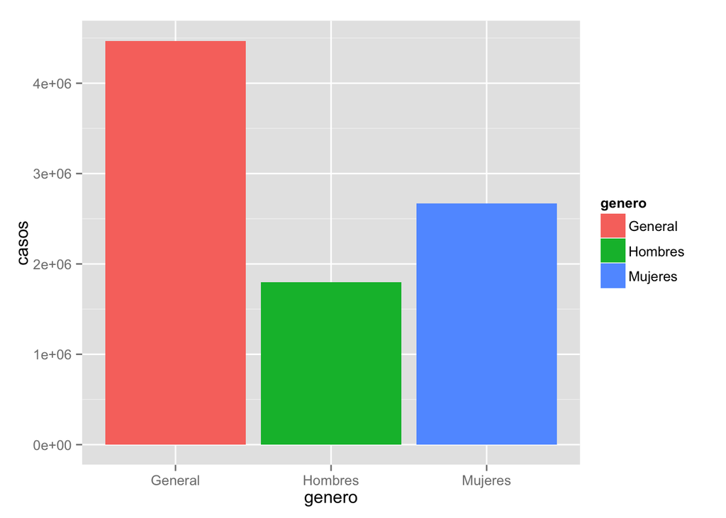

En el anio 2003 se registro el menor numero de casos de diabetes en la poblacion general, mientras que 2011 fue el anio con mas casos.  
En hombres, el menor numero se registro en 2003 y el mayor en 2009.  
En mujeres, el menor numero se registro en 2013 y el mayor en 2011.

```
##     Hombres Mujeres General
## min    2003    2013    2003
## max    2009    2011    2011
```

El promedio de casos registrados por anio en hombres, mujeres y a nivel general es el siguente:

```
##    General  Mujeres  Hombres
## 1 406220.8 242877.9 163342.9
```

La tendencia a lo largo del tiempo en hombres y mujeres:

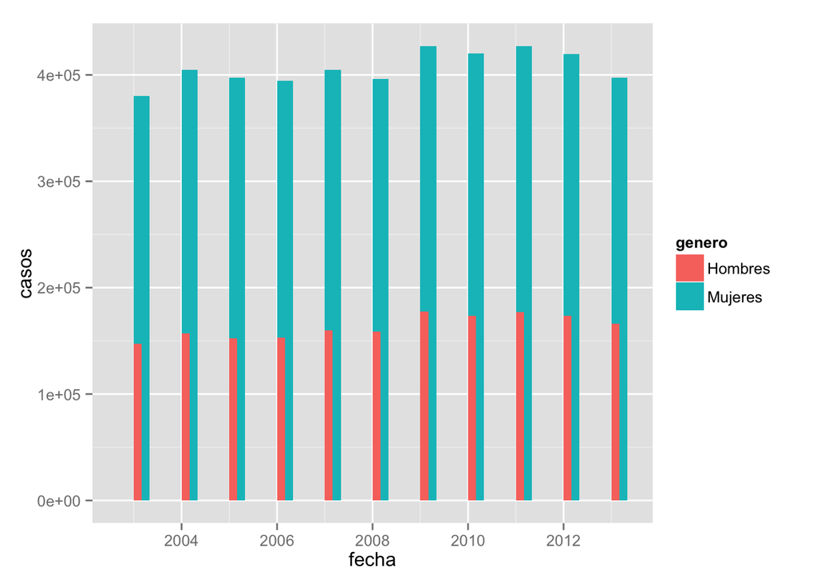

Podemos concluir, de este analisis, que la tendencia a nivel general es creciente.

Los estados que reportan el mayor y menor numero de casos son los siguientes:

```
##     Hombres Mujeres General
## min  Colima  Colima  Colima
## max  Mexico  Mexico  Mexico
```

El porcentaje de casos reportados por estado de la republica en el periodo 2003-2013:

```
##                 Estado    General
## 15              Mexico 12.5940235
## 9     Distrito Federal  8.7529644
## 14             Jalisco  7.9608739
## 30            Veracruz  5.3658903
## 21              Puebla  4.2377757
## 11          Guanajuato  4.0979951
## 8            Chihuahua  3.9198340
## 19          Nuevo Leon  3.8524502
## 5             Coahuila  3.5855331
## 25             Sinaloa  3.5653470
## 2      Baja California  3.4163237
## 28          Tamaulipas  3.4089162
## 12            Guerrero  3.3625241
## 7              Chiapas  3.0118863
```

[output cut: 18 more lines]

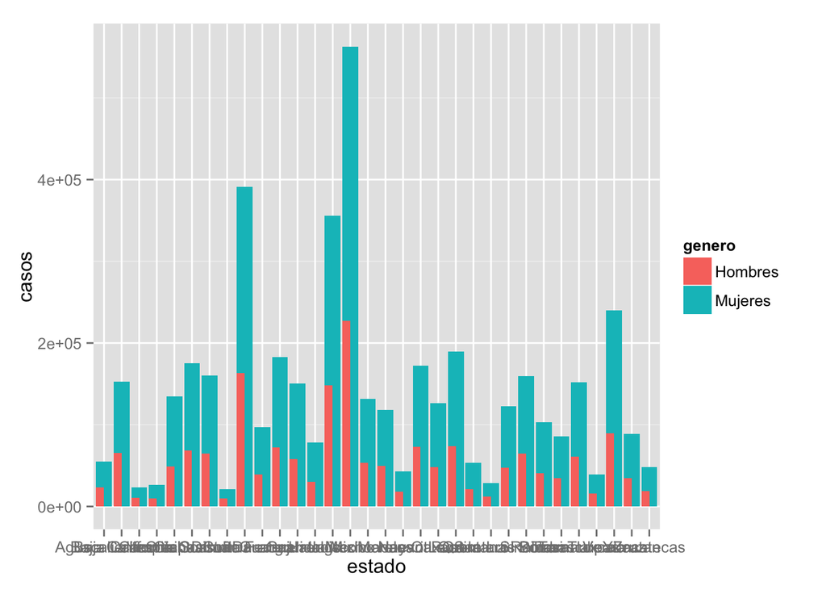

En ningun estado es mayor el numero de casos en hombres que en mujeres.

##### Analisis por Tipo de Fuente

El mayor numero de casos reportados por las instituciones del pais se dio de manera siguente:

```
##     estado  genero fecha fuente casos
## 303 Mexico General  2012  salud 28024
```

```
##      estado  genero fecha fuente casos
## 1039 Mexico Hombres  2013  salud 10869
```

```
##     estado  genero fecha fuente casos
## 655 Mexico Mujeres  2012  salud 17423
```

```
##     Fuente    General
## 2 imss.ord 36.9978800
## 1    salud 33.7964864
## 3   issste 14.6857430
## 9    otras  8.3896600
## 4  imss.op  2.8813035
## 5      dif  1.6263882
## 7   sedena  0.8615780
## 6    pemex  0.5385562
## 8    semar  0.2224048
```

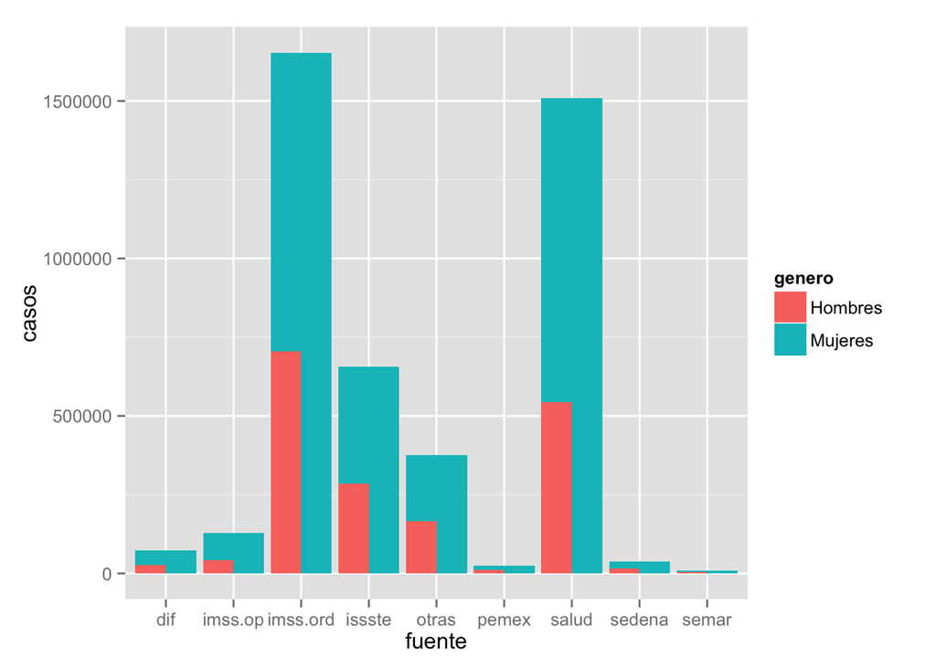

A nivel general, los casos tienen el siguiente comportamiento:

```
##    Min. 1st Qu.  Median    Mean 3rd Qu.    Max.
##       0      22     290    1602    1789   28020
```

Varianza.

```
## [1] 8249738
```

Desviacion estandar.

```
## [1] 2872.236
```

Entonces podemos decir que, a nivel general los casos se encuentran cerca de la media. Sin embargo existen muchos casos atipicos.

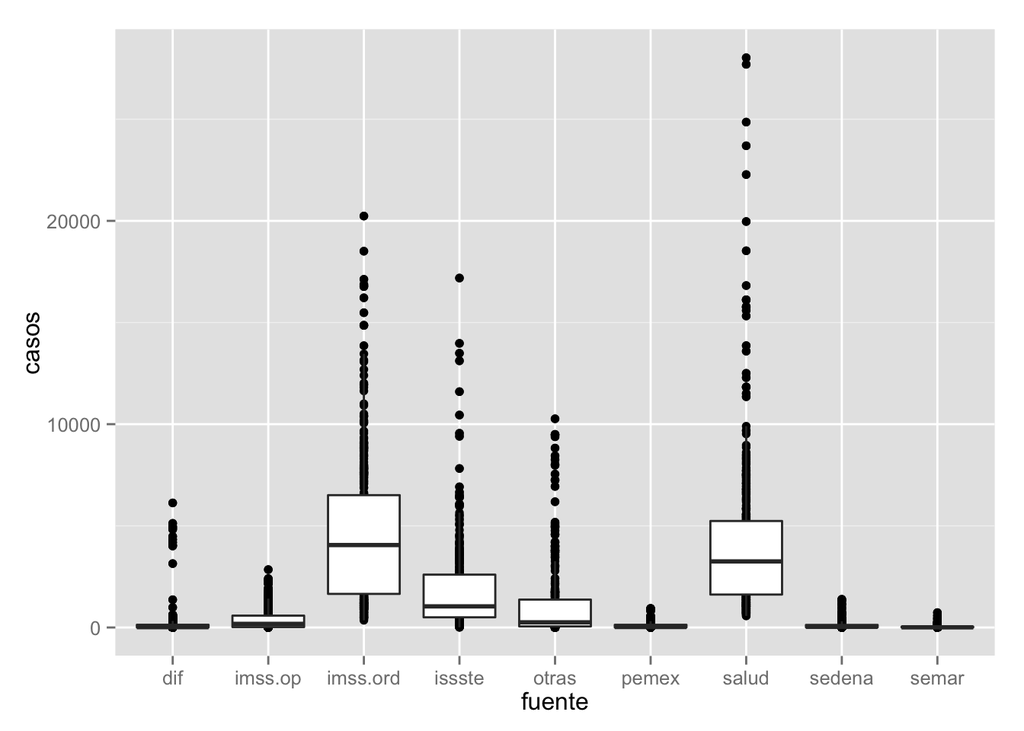

En hombres, el comportamiento es el siguinte:

```
##    Min. 1st Qu.  Median    Mean 3rd Qu.    Max.
##     0.0     8.0   119.0   644.2   721.0 10870.0
```

Varianza.

```
## [1] 1343917
```

Desviacion estandar.

```
## [1] 1159.274
```

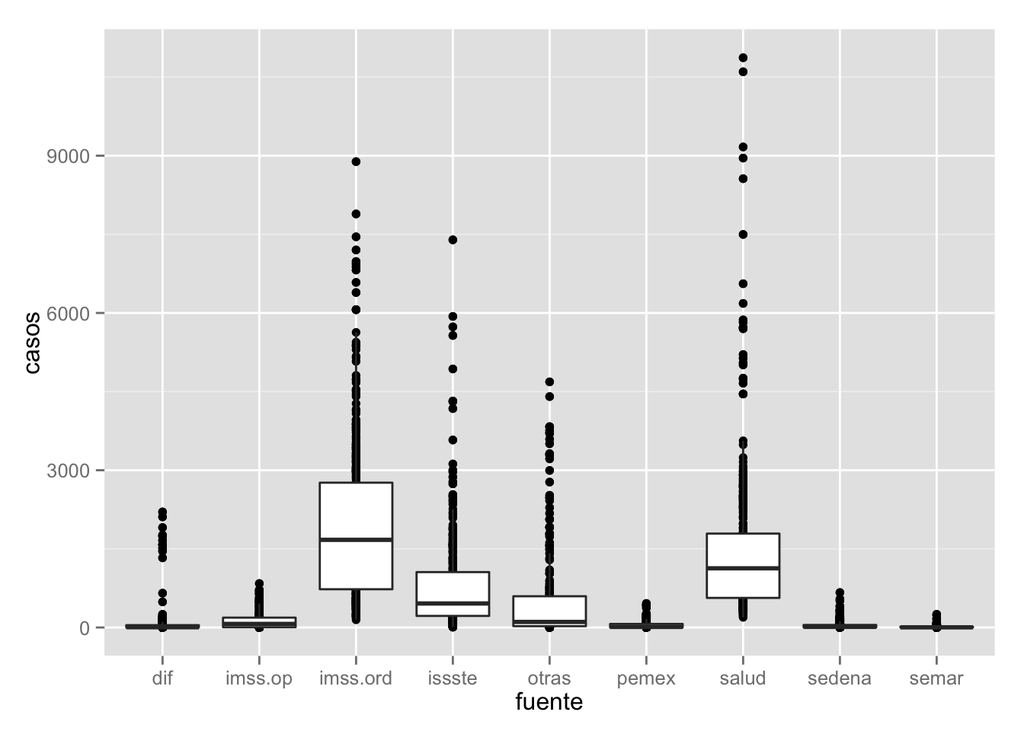

La variacion es menor, asi como la media, en comparacion con el general. Sin embargo, el comportamiento de los casos en hombres en cada una de las instituciones es muy similar al general, es decir, los la mayoria de los datos se encuentran cerca de la media pero con gran cantidad de casos atipicos.

En mujeres:

```
##    Min. 1st Qu.  Median    Mean 3rd Qu.    Max.
##     0.0    13.0   175.0   957.9  1074.0 17420.0
```

Varianza.

```
## [1] 2983395
```

Desviacion estandar.

```
## [1] 1727.251
```

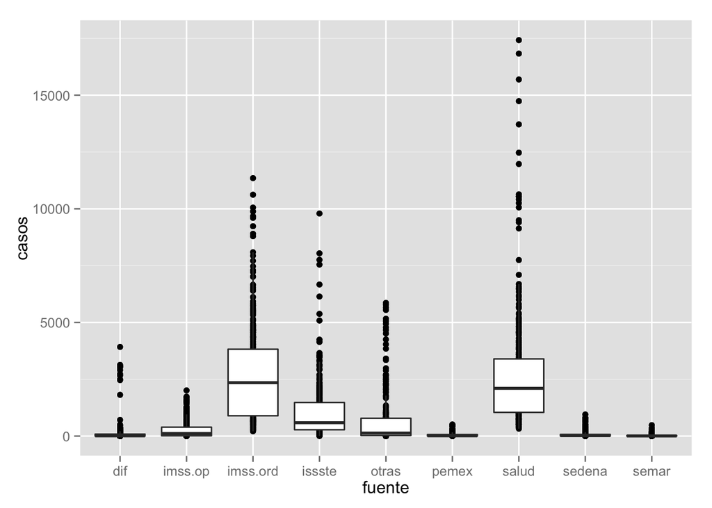

Por ultimo, se presenta el promedio de casos anual en cada una de las instituciones:

```
##     Fuente    General
## 2 imss.ord 4696.65909
## 1    salud 4290.26136
## 3   issste 1864.26705
## 9    otras 1167.86916
## 4  imss.op  406.14826
## 5      dif  277.38168
## 7   sedena  109.68376
## 6    pemex  106.48230
## 8    semar   38.82031
```

##### Analisis por Mes

El mayor numero de casos reportados ha sido en el mes de:

```
##      estado  genero fecha mes casos
## 7663 Mexico General  2011 ago  6667
```

```
##      estado  genero fecha mes casos
## 8015 Mexico Hombres  2011 ago  2858
```

```
##      estado  genero fecha mes casos
## 8367 Mexico Mujeres  2011 ago  3809
```

El porcentaje reportes de diabetes se distribuye por cada mes de la siguiente manera:

```
##    Mes  General
## 3  mar 9.077486
## 6  jun 8.914162
## 5  may 8.629834
## 10 oct 8.626947
## 8  ago 8.600070
## 7  jul 8.583531
## 4  abr 8.461184
## 1  ene 8.417612
## 2  feb 8.152485
## 9  sep 8.143287
## 11 nov 7.849157
## 12 dic 6.544246
```

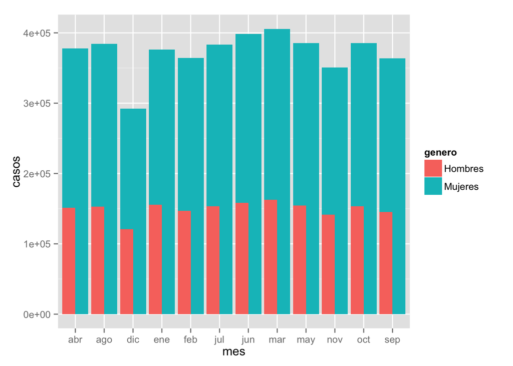

A nivel general, los casos tienen el siguiente comportamiento mensualmente:

```
##    Min. 1st Qu.  Median    Mean 3rd Qu.    Max.
##      68     417     902    1058    1282    6667
```

Varianza.

```
## [1] 821022.5
```

Desviacion estandar.

```
## [1] 906.1029
```

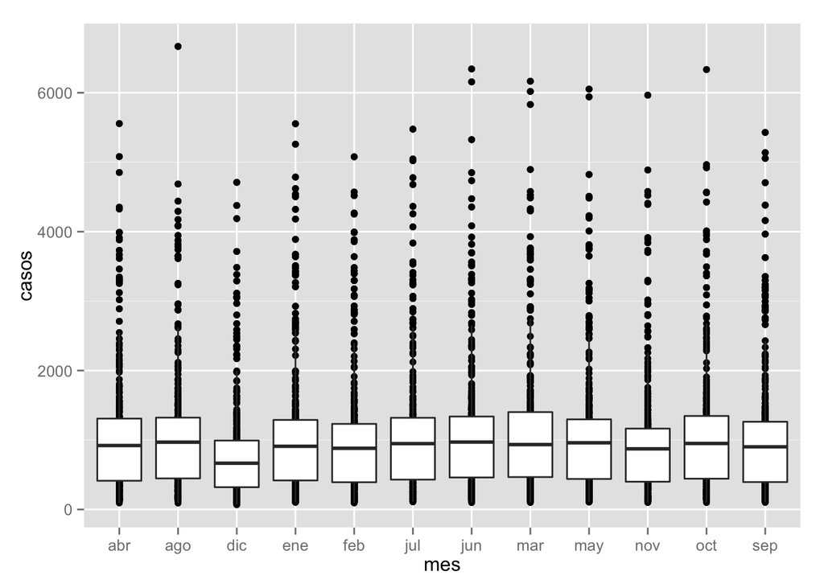

En hombres, el comportamiento es el siguinte:

```
##    Min. 1st Qu.  Median    Mean 3rd Qu.    Max.
##    29.0   169.8   354.0   425.4   513.0  2858.0
```

Varianza.

```
## [1] 137395.6
```

Desviacion estandar.

```
## [1] 370.6691
```

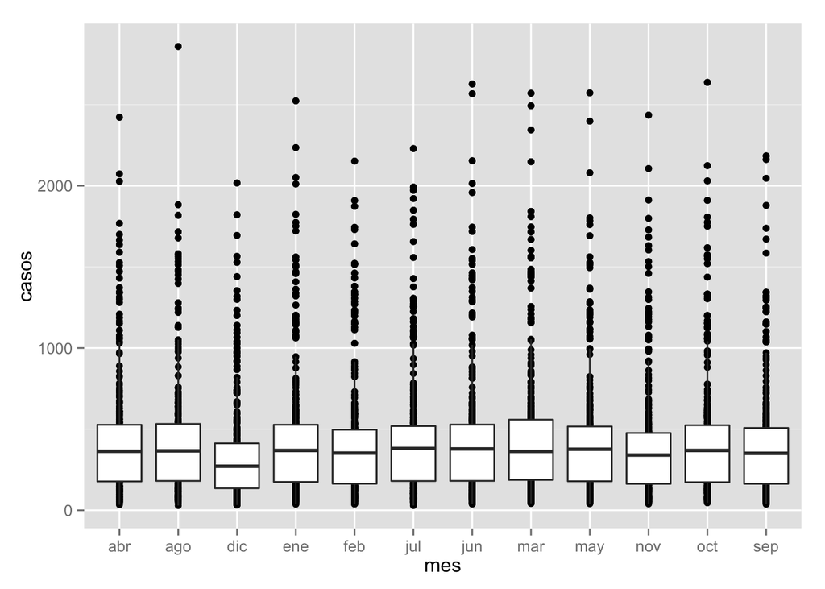

En mujeres:

```
##    Min. 1st Qu.  Median    Mean 3rd Qu.    Max.
##    36.0   248.0   540.0   632.5   769.2  3809.0
```

Varianza.

```
## [1] 289720.9
```

Desviacion estandar.

```
## [1] 538.2572
```

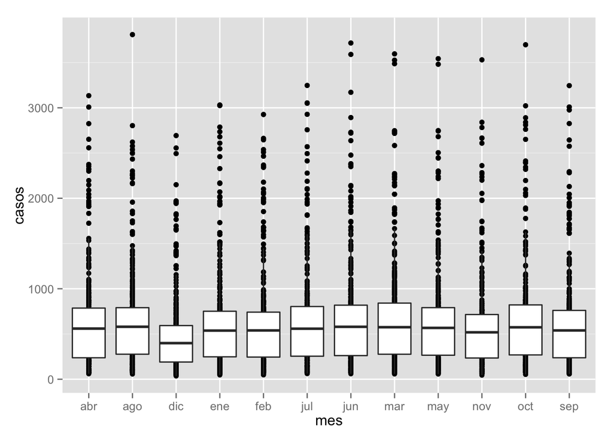

Por ultimo, se presenta el promedio mensual:

```
##    Mes   General
## 3  mar 1152.3324
## 6  jun 1131.5994
## 5  may 1095.5057
## 10 oct 1095.1392
## 8  ago 1091.7273
## 7  jul 1089.6278
## 4  abr 1074.0966
## 1  ene 1068.5653
## 2  feb 1034.9091
## 9  sep 1033.7415
## 11 nov  996.4034
## 12 dic  830.7528
```

##### Analisis por Edad

El mayor numero de casos reportados por grupo de edad es::

```
##      estado  genero fecha  edad casos
## 8463 Mexico General  2012 50a59 17236
```

```
##      estado  genero fecha  edad casos
## 8847 Mexico Hombres  2013 50a59  7087
```

```
##      estado  genero fecha  edad casos
## 9071 Mexico Mujeres  2009 50a59 10290
```

El porcentaje reportes de diabetes se distribuye por cada grupo de edad de la siguiente manera:

```
##     Edad     General
## 9  50a59 28.82836451
## 11   65+ 21.45237174
## 7  25a44 21.18171733
## 8  45a49 13.75691546
## 10 60a64 13.39168643
## 6  20a24  0.85050025
## 12   ign  0.23106555
## 5  15a19  0.18583713
## 4  10a14  0.06203523
## 3    5a9  0.02607180
## 2    1a4  0.01788100
## 1     <1  0.01555356
```

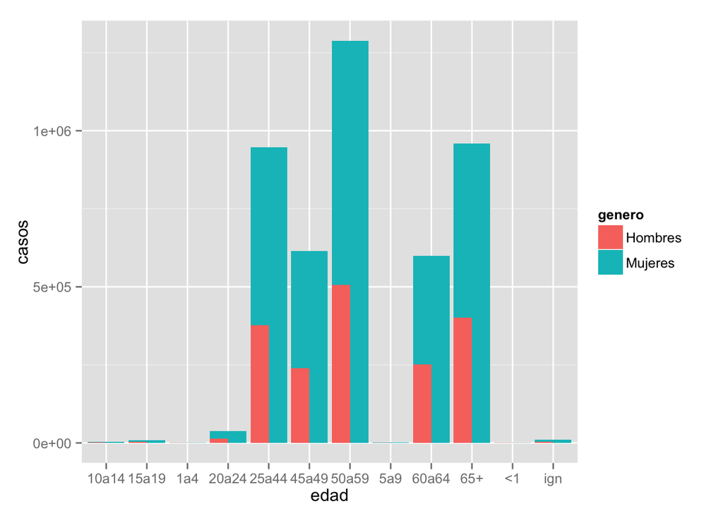

A nivel general, los casos tienen el siguiente comportamiento por grupo de esdad:

```
##    Min. 1st Qu.  Median    Mean 3rd Qu.    Max.
##     0.0     3.0    60.5  1082.0  1618.0 17240.0
```

Varianza.

```
## [1] 3756380
```

Desviacion estandar.

```
## [1] 1938.138
```

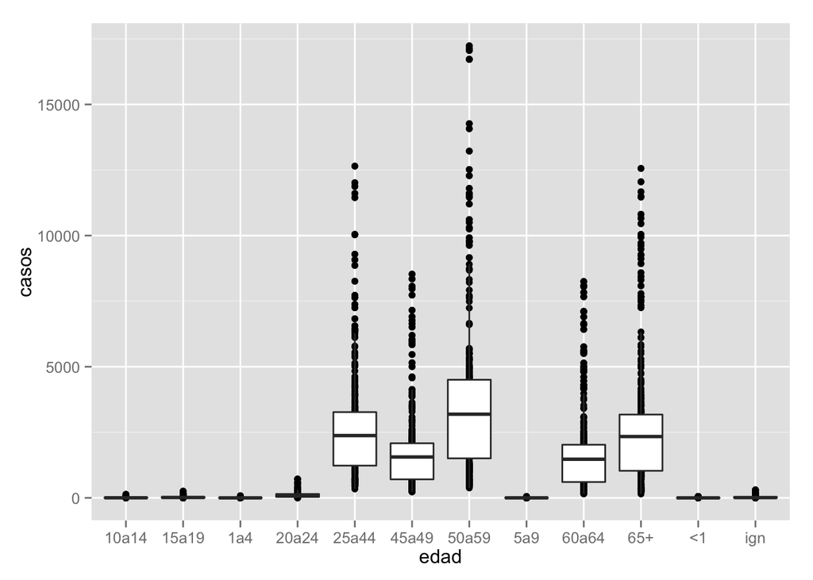

En hombres, el comportamiento es el siguinte:

```
##    Min. 1st Qu.  Median    Mean 3rd Qu.    Max.
##     0.0     1.0    22.0   435.3   647.2  7087.0
```

Varianza.

```
## [1] 616246.8
```

Desviacion estandar.

```
## [1] 785.0139
```

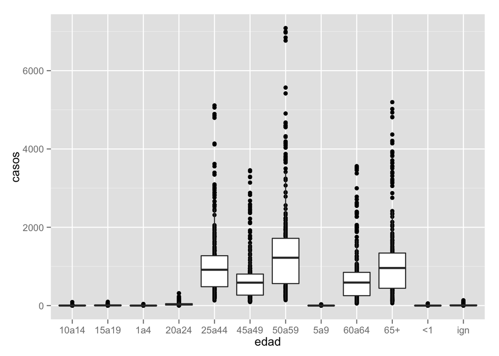

En mujeres:

```
##    Min. 1st Qu.  Median    Mean 3rd Qu.    Max.
##     0.0     1.0    38.0   647.2   963.5 10290.0
```

Varianza.

```
## [1] 1337848
```

Desviacion estandar.

```
## [1] 1156.654
```

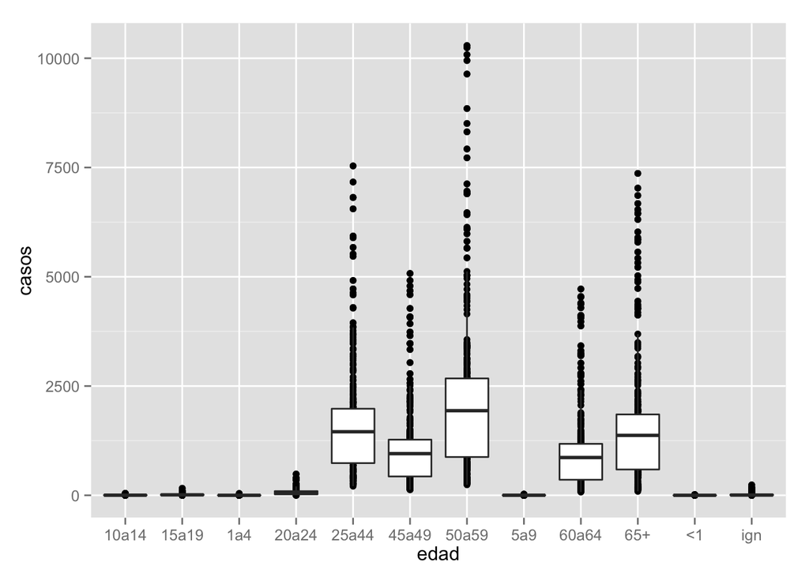

Por ultimo, se presenta el promedio por grupo de edad:

```
##     Edad     General
## 9  50a59 3659.588068
## 11   65+ 2723.250000
## 7  25a44 2688.892045
## 8  45a49 1746.357955
## 10 60a64 1699.994318
## 6  20a24  107.965909
## 12   ign   29.332386
## 5  15a19   23.590909
## 4  10a14    7.875000
## 3    5a9    3.640625
## 2    1a4    2.496875
## 1     <1    2.171875
```